# H-1B Visa Application

# 1 Introduction

The H-1B is a non -immigrant visa program in the United States that allows employers to employ foreign workers. The program is aimed towards professionals with a “theoretical and practical applications of a body of highly specialized knowledge” This program allows companies in the United States to hire foreign professionals with specific skills and expertise across various industries and locations (“H-1B Employer Data Hub,” n.d.).

# 2 Analysis

## 2.1 Trends

The analysis of H-1B applications for the fiscal years, 2020 - 2024, reveals some patterns:

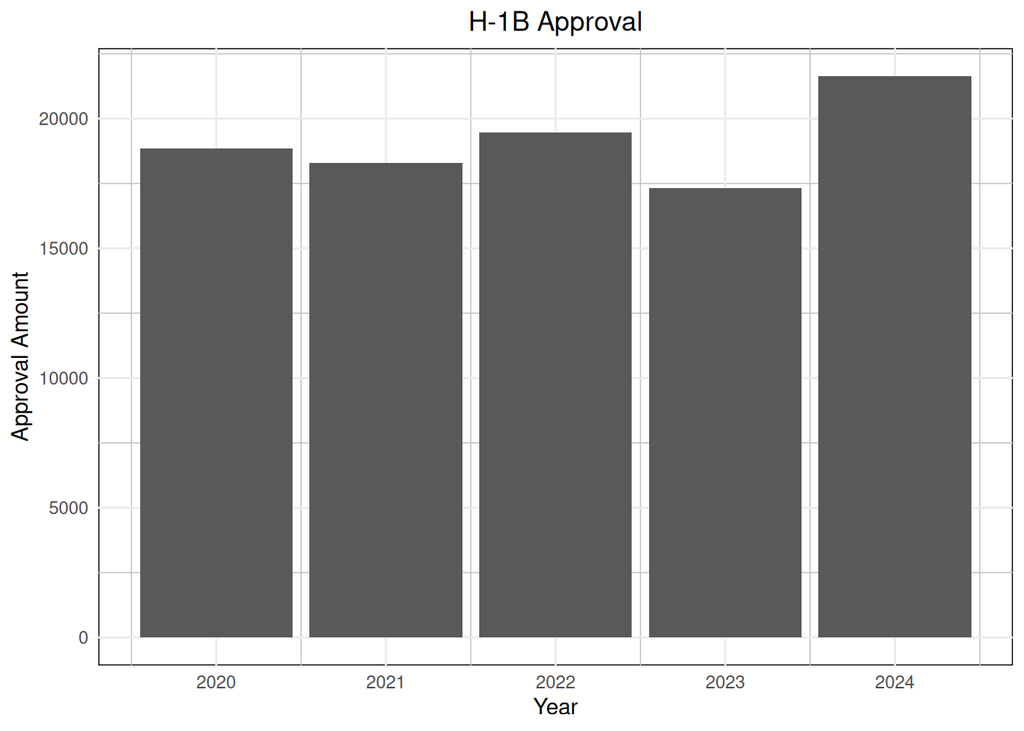

Figure 1: The total number of H-1B Visa Approvals

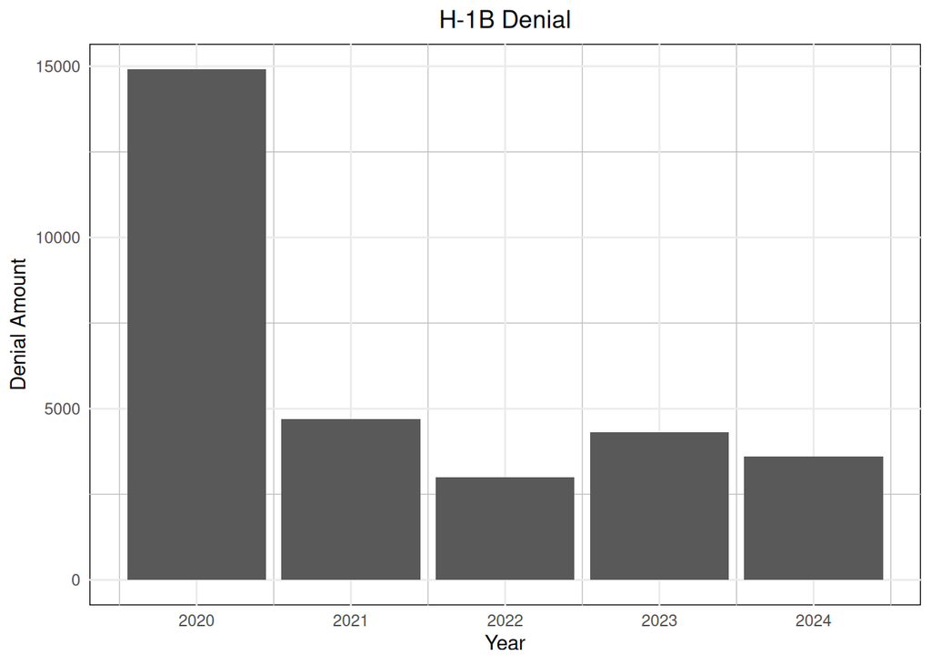

Figure 2: The total number of H-1B Visa Denials

| Fiscal.Year | approval | denial | total_applications | approvalRate | denialRate |
| --- | --- | --- | --- | --- | --- |
| 2020 | 18841 | 14911 | 33752 | 56 | 44 |
| 2021 | 18280 | 4690 | 22970 | 80 | 20 |
| 2022 | 19468 | 2988 | 22456 | 87 | 13 |
| 2023 | 17314 | 4309 | 21623 | 80 | 20 |
| 2024 | 21636 | 3611 | 25247 | 86 | 14 |

TRUE

Table 1: Summary Statistics of H-1B Visa Program

```
    Pearson's Chi-squared test

data:  table
X-squared = 10538, df = 4, p-value < 2.2e-16
```

Table 2: Chisqaure Test

Overall, the approval rates have increased while denials have decreased. The trend suggest a shift in H-1B visa processing policies and practices over the 5 year period, with a clear move towards higher approval rates and fewer denials.

The chi-square test helps to determine if the observed changes in approval and denial rates are statically significant or merely random chance. This is crucial because:

- it validates the trends
- provides evidence to support the claims about the changes

The p-value, <2.2e-16, suggests that the approval and denial rate is not due too random chance.

## 2.2 Distribution

### 2.2.1 Distribution per State (Top 5 State)

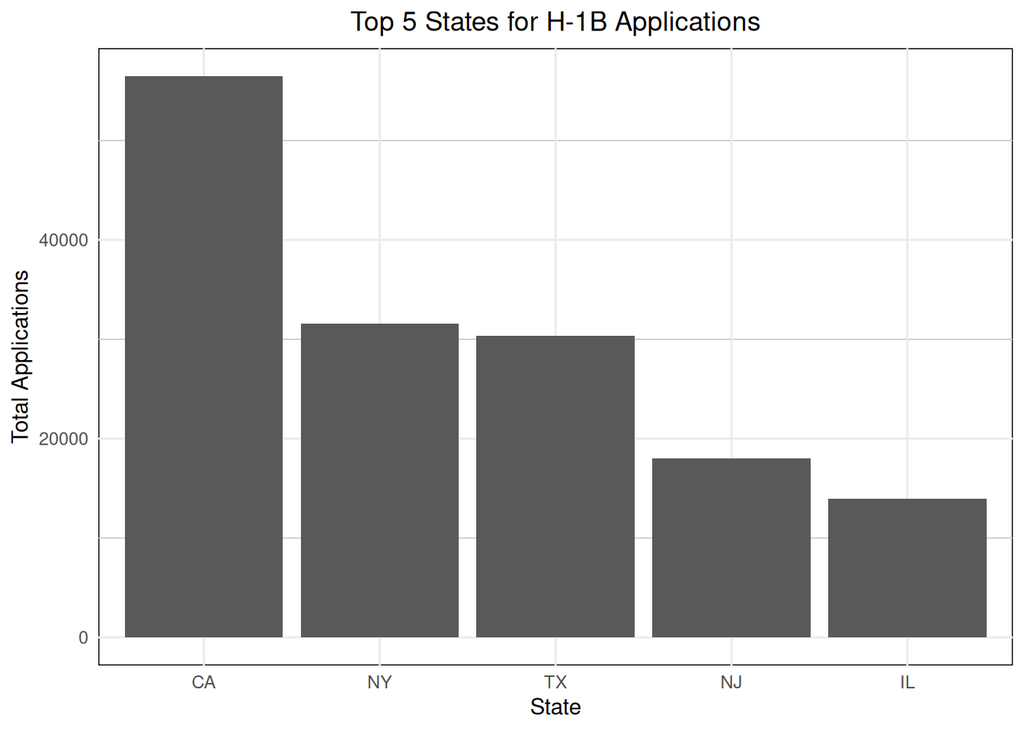

Figure 3: Distribution per State

### 2.2.2 Distribution per Industry (Top 5 Industries)

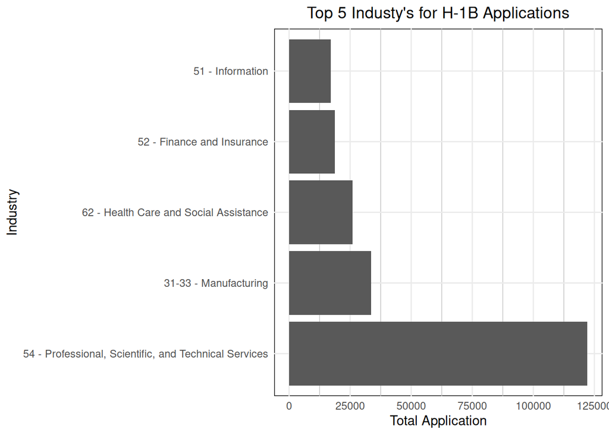

Figure 4: Distribution per Industry

# 3 Conclusion

The statistical evidence strengthens the conclusion that there has been a substantial shift in the H-1B processing, with a clear trend towards higher approval rates and lower denial rates.

## References

“H-1B Employer Data Hub.” n.d. U.S. Citizenship; Immigration Services (USCIS). https://www.uscis.gov/tools/reports-and-studies/h-1b-employer-data-hub.